# Term Deposit Prediction

## Term Deposit Purchase Prediction

Banks usually run some direct marketing campaigns to improve customer subscription of term deposits. The dataset used here is from a direct marketing campaign of a Portuguese banking institution. The marketing campaigns were based on phone calls. The objective is to predict whether a given customer has subscribed to a term deposit or not.

This is a supervised classification problem. The dataset is also imbalanced - The number of 'not subscribed' category is very high compared to number of 'not subscribed' category.

### Techniques used for handling imbalanced dataset

1> Random Under Sampling (RUS)

2> Random Over Sampling (ROS)

3> Under sampling - Tomek Links

4> SMOTE (Synthetic Minority Oversampling Technique)

5> NearMiss

6> Penalized SVM

### Scoring

As dataset is imbalanced, F1-Score is used as it is a more apt scoring method than Accuracy score.

```python
import pandas as pd
import numpy as np

import matplotlib.pyplot as plt
import seaborn as sns

from collections import Counter
from imblearn.under_sampling import RandomUnderSampler, TomekLinks, NearMiss
from imblearn.over_sampling import RandomOverSampler, SMOTE

from sklearn.linear_model import LogisticRegression
from sklearn.svm import SVC
from sklearn.ensemble import RandomForestClassifier
from sklearn.model_selection import train_test_split, KFold, cross_val_score
from sklearn.metrics import f1_score, classification_report, confusion_matrix
```

**About the dataset**

The dataset used here is taken from https://archive.ics.uci.edu/dataset/222/bank+marketing. It contains customer and campaign details.

```python
df = pd.read_csv("bank-full.csv", sep=';', header=0)
df.head()
```

|  | age | job | marital | education | default | balance | housing | loan | contact | day | month | duration | campaign | pdays | previous | poutcome | y |
| --- | --- | --- | --- | --- | --- | --- | --- | --- | --- | --- | --- | --- | --- | --- | --- | --- | --- |
| 0 | 58 | management | married | tertiary | no | 2143 | yes | no | unknown | 5 | may | 261 | 1 | -1 | 0 | unknown | no |
| 1 | 44 | technician | single | secondary | no | 29 | yes | no | unknown | 5 | may | 151 | 1 | -1 | 0 | unknown | no |
| 2 | 33 | entrepreneur | married | secondary | no | 2 | yes | yes | unknown | 5 | may | 76 | 1 | -1 | 0 | unknown | no |
| 3 | 47 | blue-collar | married | unknown | no | 1506 | yes | no | unknown | 5 | may | 92 | 1 | -1 | 0 | unknown | no |
| 4 | 33 | unknown | single | unknown | no | 1 | no | no | unknown | 5 | may | 198 | 1 | -1 | 0 | unknown | no |

##### Attributes of data

**bank client data:**

1 - age (numeric)

2 - job : type of job (categorical: "admin.","unknown","unemployed","management","housemaid","entrepreneur","student", "blue-collar","self-employed","retired","technician","services")

3 - marital : marital status (categorical: "married","divorced","single"; note: "divorced" means divorced or widowed)

4 - education (categorical: "unknown","secondary","primary","tertiary")

5 - default: has credit in default? (binary: "yes","no")

6 - balance: average yearly balance, in euros (numeric)

7 - housing: has housing loan? (binary: "yes","no")

8 - loan: has personal loan? (binary: "yes","no")

**related with the last contact of the current campaign:**

9 - contact: contact communication type (categorical: "unknown","telephone","cellular")

10 - day: last contact day of the month (numeric)

11 - month: last contact month of year (categorical: "jan", "feb", "mar", ..., "nov", "dec")

12 - duration: last contact duration, in seconds (numeric)

**other attributes:**

13 - campaign: number of contacts performed during this campaign and for this client (numeric, includes last contact)

14 - pdays: number of days that passed by after the client was last contacted from a previous campaign (numeric, -1 means client was not previously contacted)

15 - previous: number of contacts performed before this campaign and for this client (numeric)

16 - poutcome: outcome of the previous marketing campaign (categorical: "unknown","other","failure","success")

**Output variable (desired target):**

17 - y - has the client subscribed a term deposit? (binary: "yes","no")

### Exploratory Data Analysis

We analyze relationships between data variables. This would help in deciding the pre-processing and model development steps.

#### 1> Understanding target variable - Subscription Status

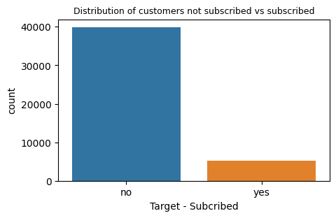

```python
plt.figure(figsize=(5,3))
sns.countplot(x='y', data = df)
plt.title("Distribution of customers not subscribed vs subscribed", fontsize=9)
plt.xlabel("Target - Subcribed")
plt.show()
```

```python
df['y'].value_counts(normalize=True).mul(100).round(2).astype(str)+'%'
```

```
no     88.3%
yes    11.7%
Name: y, dtype: object
```

**Observation:** Distribution of target variable indicates about 88.3% of customers have not subscribed and only 11.7% customers have subscribed. Hence the target variable is highly imbalanced. Suitable machine learning techniques needs to be used for prediction.

#### 2> Understanding distribution of numeric variables

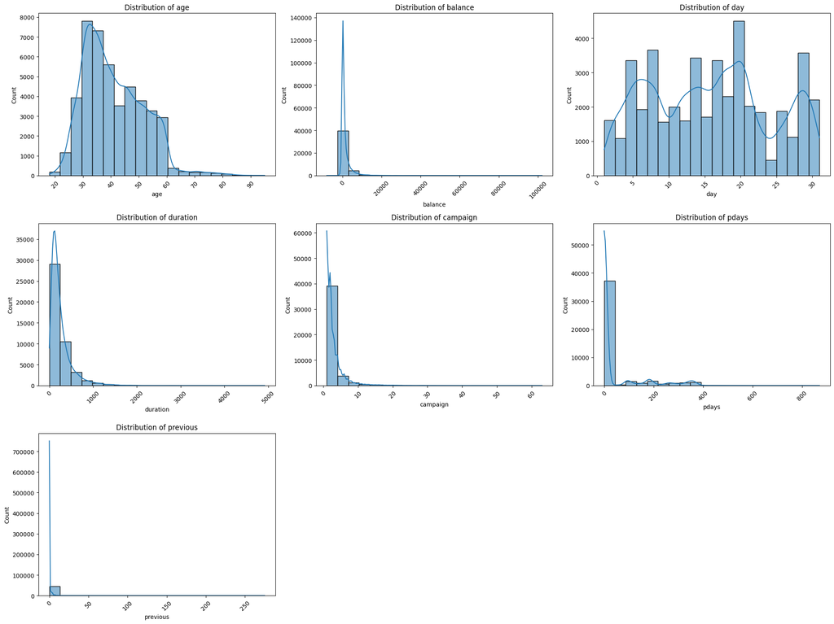

```python
# List of numeric features
numeric_features = ['age', 'balance', 'day', 'duration', 'campaign', 'pdays', 'previous']

# Plotting histograms for numeric features
plt.figure(figsize=(20, 15))
for i, feature in enumerate(numeric_features, 1):
    plt.subplot(3, 3, i)
    sns.histplot(df[feature], bins=20, kde=True)
    plt.title(f'Distribution of {feature}')
    plt.xticks(rotation=45)
plt.tight_layout()
plt.show()
```

#### 3> Understanding distribution of categorical variables

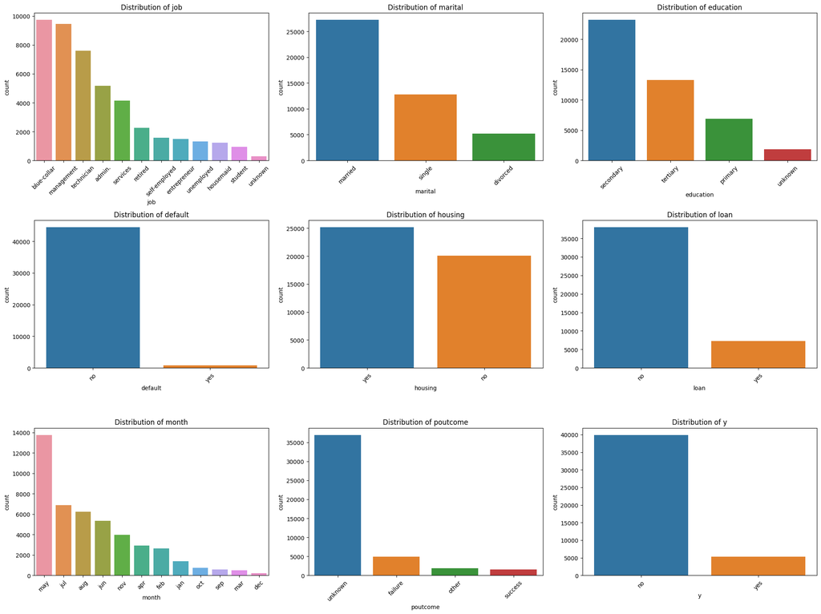

```python
# List of categorical features
categorical_features = ['job', 'marital', 'education', 'default', 'housing', 'loan', 'month', 'poutcome', 'y']

# Plotting bar charts for categorical features
plt.figure(figsize=(20, 15))
for i, feature in enumerate(categorical_features, 1):
    plt.subplot(3, 3, i)
    sns.countplot(data=df, x=feature, order=df[feature].value_counts().index)
    plt.title(f'Distribution of {feature}')
    plt.xticks(rotation=45)
plt.tight_layout()
plt.show()
```

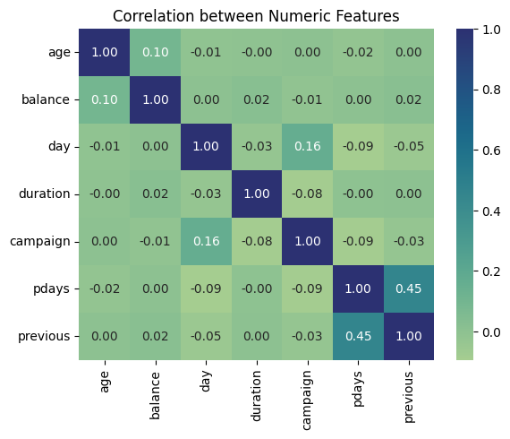

```python
# Generate a correlation heatmap for numeric features and the response variable
sns.heatmap(df[numeric_features + ['y']].corr(), annot=True, cmap='crest', fmt='0.2f')
plt.title('Correlation between Numeric Features')
```

```python
# Creating 'Age Group' feature
bins = [18, 30, 40, 50, 60, 100]
labels = ['18-30', '31-40', '41-50', '51-60', '61+']
df['age_group'] = pd.cut(df['age'], bins=bins, labels=labels, right=False)

# Creating 'Season' feature
month_to_season = {
    'jan': 'Winter', 'feb': 'Winter', 'mar': 'Spring',
    'apr': 'Spring', 'may': 'Spring', 'jun': 'Summer',
    'jul': 'Summer', 'aug': 'Summer', 'sep': 'Autumn',
    'oct': 'Autumn', 'nov': 'Autumn', 'dec': 'Winter'
}
df['season'] = df['month'].map(month_to_season)
```

```python
# One hot encoding for categorical variables
data_encoded = pd.get_dummies(data=df, columns=['job', 'marital', 'education', 'default', 'contact', 'housing', 'loan', 'month', 'poutcome'] + ['age_group', 'season'], prefix='OHE', prefix_sep='_', drop_first=True)
```

```python
# Create training and test datasets
X = data_encoded.drop(columns='y')
y = data_encoded['y'].map({'no':0, 'yes':1})

X_train, X_test, y_train , y_test = train_test_split(X, y, test_size=0.2, random_state=42)
X_train.shape, X_test.shape
```

```
((36168, 49), (9043, 49))
```

```python
# Logistic regression, Support Vector Classifier, Random Forest Classifier models are used for classification and 5-Fold cross validation is used
lr_model = LogisticRegression(max_iter=5000)
svm = SVC(kernel='rbf', C=1, random_state=42)
rf = RandomForestClassifier(n_estimators=100, random_state=42)
cv = KFold(n_splits=5, random_state=1, shuffle=True)
```

```python
# Dataframe to store results of each model
results = pd.DataFrame(columns=['Model', 'Cross_Val_score', 'Test_score'])
```

**No strategy to handle class imbalance**

Basic models are used - Logistic Regression, SVM, Random Forest Classifier

```python
scores_lr = cross_val_score(lr_model, X_train, y_train, scoring='f1', cv=cv, n_jobs=-1)
print("Cross Validation score:", scores_lr.mean())
lr1 = lr_model.fit(X_train, y_train)
f1_lr = f1_score(y_test, lr1.predict(X_test))
print("F1 score on test data:", f1_lr)
results = pd.concat([results, pd.DataFrame([['LR-Base', scores_lr.mean(), f1_lr]], columns=results.columns)], ignore_index=True)
```

```
Cross Validation score: 0.4502278865651629
F1 score on test data: 0.45465393794749404
```

```python
scores_svm = cross_val_score(svm, X_train, y_train, scoring='f1', cv=cv, n_jobs=-1)
print("Cross Validation score:", scores_svm.mean())
svm = svm.fit(X_train, y_train)
f1_svm = f1_score(y_test, svm.predict(X_test))
print("F1 score on test data:", f1_svm)
results = pd.concat([results, pd.DataFrame([['SVM-Base', scores_svm.mean(), f1_svm]], columns=results.columns)], ignore_index=True)
```

```
Cross Validation score: 0.010816273203098862
F1 score on test data: 0.012681159420289856
```

```python
scores_rf = cross_val_score(rf, X_train, y_train, scoring='f1', cv=cv, n_jobs=-1)
print("Cross Validation score:", scores_rf.mean())
rf = rf.fit(X_train, y_train)
f1_rf = f1_score(y_test, rf.predict(X_test))
print("F1 score on test data:", f1_rf)
results = pd.concat([results, pd.DataFrame([['RF-Base', scores_rf.mean(), f1_rf]], columns=results.columns)], ignore_index=True)
```

```
Cross Validation score: 0.4892552512534909
F1 score on test data: 0.5146726862302483
```

```python
results
```

|  | Model | Cross_Val_score | Test_score |
| --- | --- | --- | --- |
| 0 | LR-Base | 0.450228 | 0.454654 |
| 1 | SVM-Base | 0.010816 | 0.012681 |
| 2 | RF-Base | 0.489255 | 0.514673 |

### Handling Imbalanced dataset

EDA indicates that the target classes are in the ratio 88%:12%. This is an imbalanced dataset. A number of techniques are employed to address this issue.

**Technique 1 - Random under sampling**

Under sample the majority class by randomly picking samples with or without replacement

```python
rus = RandomUnderSampler(random_state=42, replacement=True)
x_rus, y_rus = rus.fit_resample(X_train, y_train)

print('Original dataset shape:', Counter(y))
print('Resample dataset shape', Counter(y_rus))
```

```
Original dataset shape: Counter({0: 39922, 1: 5289})
Resample dataset shape Counter({0: 4198, 1: 4198})
```

```python
scores_lr_rus = cross_val_score(lr_model, x_rus, y_rus, scoring='f1', cv=cv, n_jobs=-1)
print("Cross Validation Score-RUS:", scores_lr_rus.mean())
lr2 = lr_model.fit(x_rus, y_rus)
f1_lr_rus = f1_score(y_test, lr2.predict(X_test))
print("F1 score on test data:", f1_lr_rus)
results = pd.concat([results, pd.DataFrame([['LR-Rus', scores_lr_rus.mean(), f1_lr_rus]], columns=results.columns)], ignore_index=True)
```

```
Cross Validation Score-RUS: 0.8292078416298139
F1 score on test data: 0.5561694290976059
```

**Technique 2 - Random over Sampling**

Generate new samples in the minority classes by random sampling with the replacement of the currently available samples.

```python
ros = RandomOverSampler(random_state=42)
x_ros, y_ros = ros.fit_resample(X_train, y_train)

print('Original dataset shape:', Counter(y))
print('Resample dataset shape', Counter(y_ros))
```

```
Original dataset shape: Counter({0: 39922, 1: 5289})
Resample dataset shape Counter({0: 31970, 1: 31970})
```

```python
scores_lr_ros = cross_val_score(lr_model, x_ros, y_ros, scoring='f1', cv=cv, n_jobs=-1)
print("Cross Validation Score-ROS:", scores_lr_ros.mean())
lr2 = lr_model.fit(x_ros, y_ros)
f1_lr_ros = f1_score(y_test, lr2.predict(X_test))
print("F1 score on test data:", f1_lr_ros)
results = pd.concat([results, pd.DataFrame([['LR-Ros', scores_lr_ros.mean(), f1_lr_ros]], columns=results.columns)], ignore_index=True)
```

```
Cross Validation Score-ROS: 0.8341441369303503
F1 score on test data: 0.5581538461538462
```

```python
results
```

|  | Model | Cross_Val_score | Test_score |
| --- | --- | --- | --- |
| 0 | LR-Base | 0.450228 | 0.454654 |
| 1 | SVM-Base | 0.010816 | 0.012681 |
| 2 | RF-Base | 0.489255 | 0.514673 |
| 3 | LR-Rus | 0.829208 | 0.556169 |
| 4 | LR-Ros | 0.834144 | 0.558154 |

```python
tl = RandomOverSampler(sampling_strategy='not minority')
x_tl, y_tl = tl.fit_resample(X_train, y_train)
print('Original dataset shape', Counter(y))
print('Resample dataset shape', Counter(y_tl))

scores_lr_tl = cross_val_score(lr_model, x_tl, y_tl, scoring='f1', cv=cv, n_jobs=-1)
print("Cross Validation Score-TL:", scores_lr_tl.mean())
lr4 = lr_model.fit(x_tl, y_tl)
f1_lr_tl = f1_score(y_test, lr4.predict(X_test))
print("F1 score on test data:", f1_lr_tl)
results = pd.concat([results, pd.DataFrame([['LR-TomekLinks', scores_lr_tl.mean(), f1_lr_tl]], columns=results.columns)], ignore_index=True)
```

```
Original dataset shape Counter({0: 39922, 1: 5289})
Resample dataset shape Counter({0: 31970, 1: 4198})
Cross Validation Score-TL: 0.4502278865651629
F1 score on test data: 0.45465393794749404
```

**Technique 4 - SMOTE**

This technique generates synthetic data for the minority class. SMOTE (Synthetic Minority Oversampling Technique) works by randomly picking a point from the minority class and computing the k-nearest neighbors for this point. The synthetic points are added between the chosen point and its neighbors.

```python
smote = SMOTE()
x_smote, y_smote = smote.fit_resample(X_train, y_train)
print('Original dataset shape', Counter(y))
print('Resample dataset shape', Counter(y_smote))

scores_lr_smote = cross_val_score(lr_model, x_smote, y_smote, scoring='f1', cv=cv, n_jobs=-1)
print("Cross Validation Score-TL:", scores_lr_smote.mean())
lr5 = lr_model.fit(x_smote, y_smote)
f1_lr_smote = f1_score(y_test, lr5.predict(X_test))
print("F1 score on test data:", f1_lr_smote)
results = pd.concat([results, pd.DataFrame([['LR-SMOTE', scores_lr_smote.mean(), f1_lr_smote]], columns=results.columns)], ignore_index=True)
```

```
Original dataset shape Counter({0: 39922, 1: 5289})
Resample dataset shape Counter({0: 31970, 1: 31970})
Cross Validation Score-TL: 0.9358682651563501
F1 score on test data: 0.4786053882725832
```

**Technique 5 - NearMiss**

NearMiss is an under-sampling technique. Instead of resampling the Minority class, using a distance will make the majority class equal to the minority class.

```python
nm = NearMiss()
x_nm, y_nm = nm.fit_resample(X_train, y_train)
print('Original dataset shape', Counter(y))
print('Resample dataset shape', Counter(y_nm))

scores_lr_nm = cross_val_score(lr_model, x_nm, y_nm, scoring='f1', cv=cv, n_jobs=-1)
print("Cross Validation Score-TL:", scores_lr_nm.mean())
lr6 = lr_model.fit(x_nm, y_nm)
f1_lr_nm = f1_score(y_test, lr6.predict(X_test))
print("F1 score on test data:", f1_lr_nm)
results = pd.concat([results, pd.DataFrame([['LR-NearMiss', scores_lr_nm.mean(), f1_lr_nm]], columns=results.columns)], ignore_index=True)
```

```
Original dataset shape Counter({0: 39922, 1: 5289})
Resample dataset shape Counter({0: 4198, 1: 4198})
Cross Validation Score-TL: 0.9058594777267166
F1 score on test data: 0.35361901332373064
```

**Penalized SVM**

During SVM training, we can use the argument class_weight=’balanced’ to penalize mistakes on the minority class by an amount proportional to how under-represented it is.

We also want to include the argument probability=True if we want to enable probability estimates for SVM algorithms.

```python
psvm = SVC(class_weight='balanced', probability=True)
scores_psvm = cross_val_score(psvm, X_train, y_train, scoring='f1', cv=cv, n_jobs=-1)
print("Cross Validation Score-PSVM:", scores_psvm.mean())
psvm = psvm.fit(X_train, y_train)
f1_psvm = f1_score(y_test, psvm.predict(X_test))
print("F1 score on test data:", f1_psvm)
results = pd.concat([results, pd.DataFrame([['Penalized SVM', scores_psvm.mean(), f1_psvm]], columns=results.columns)], ignore_index=True)
```

```
Cross Validation Score-PSVM: 0.42180497165458475
F1 score on test data: 0.42185299915516755
```

```python
results
```

|  | Model | Cross_Val_score | Test_score |
| --- | --- | --- | --- |
| 0 | LR-Base | 0.450228 | 0.454654 |
| 1 | SVM-Base | 0.010816 | 0.012681 |
| 2 | RF-Base | 0.489255 | 0.514673 |
| 3 | LR-Rus | 0.829208 | 0.556169 |
| 4 | LR-Ros | 0.834144 | 0.558154 |
| 5 | LR-TomekLinks | 0.450228 | 0.454654 |
| 6 | LR-SMOTE | 0.935868 | 0.478605 |
| 7 | LR-NearMiss | 0.905859 | 0.353619 |
| 8 | Penalized SVM | 0.421805 | 0.421853 |

**Conclusion:** Logistic Regression using Random Over Sampling technique is found to have the best model performance and hence is best suited for this dataset.